# COMPARING BAYES VS FREQ NORMAL MEAN

17 Mar 2021 (*updated: 2021-03-16)*

## Admin & Startup

## Schedule review

Let’s review the schedule and place today’s learning in context.

## Action items this week

- Read Chapter 11, 12.
- Grades are up to date. Please review and let me know if you have any questions.
- Problem Set 6, Ch. 9, 10 is due Friday, 19 Mar 2021.
- Midterm 2 (canvas quiz format) is due Friday, 19 Mar 2021, covers mainly Ch.7-10.

## Any questions over problem set 6, Ch. 9,10?

- Ch.9 #1-3,C1
- Ch.10 #2, C1,C3-C6

## Today’s plan

- Prime by reading HW 7, ch. 11,12 exercise prompts.
- Finish predictive posterior discussion.
- Discuss Ch. 12.
- Summarize, Revisit HW or Q & A

*Please contribute questions and comments*

## I. Problem Set 7, Ch. 11-13

- Ch.11 #2,5, C5-C7,
- Ch.12 #4
- Ch.13 #1,2,16

## II. 11.5 Predictive Density for Next Observation

```r
## posterior norm prior for normal mean
update_normnp <- function(m, s2, n, y_bar, sigma2){
    ## posterior precision is the sum of prior and sample precision
    total_precision <- 1/s2 + n/sigma2
    s_prime2 <- 1/total_precision
    ## posterior mean is the weighted average of prior and sample mean
    m_prime <- ( (1/s2) / total_precision ) * m + ( (n/sigma2) / total_precision ) * y_bar
    ## return as a list
    list(m_prime=m_prime, s_prime2=s_prime2, s_prime = sqrt(s_prime2))
}
## predictive distribution
compute_normnp_predictive <- function(m, s2, n, y_bar, sigma2){
    posterior_params <- update_normnp(m = m, s2 = s2, n = n, y_bar = y_bar, sigma2 = sigma2)
    ## return as a list
    list(m_nplus1 = posterior_params$m_prime, s_nplus1_2= sigma2 + posterior_params$s_prime2)
}
```

## compare posterior to predictive for sleep data

```r
sleep_times <- c(6.5, 6.5, 8, 6, 6, 6, 7, 7, 3, 7, 7, 8, 6, 9.25, 6, 7, 7, 7.5, 8, 6, 4)
mean(sleep_times)
```

```
## [1] 6.607143
```

```r
sd(sleep_times)
```

```
## [1] 1.352247
```

```r
y_bar <- mean(sleep_times)
n <- length(sleep_times)
sigma2 <- 2
s2 <- 2
m <- 7
update_normnp(m = 7, s2 = 1, n = n, y_bar = y_bar, sigma2 = 1)
```

```
## $m_prime
## [1] 6.625
##
## $s_prime2
## [1] 0.04545455
##
## $s_prime
## [1] 0.2132007
```

```r
compute_normnp_predictive(m = m, s2 = 1, n = n, y_bar = y_bar, sigma2 = 1 )
```

```
## $m_nplus1
## [1] 6.625
##
## $s_nplus1_2
## [1] 1.045455
```

## III. Ch. 12

Comparing Bayes/Frequentist Inferences for Normal Mean

The discussion centers on efficiency (measured by Mean Squared Error and estimation precision using intervals) and Statistical Testing for Bayesian and Frequentist Inferences for mean.

## 12.1

Comparing Frequentist and Bayesian Point Estimators

## Code for equations in Section 12.1

```r
## Bias of the Bayesian estimator, m_prime (the posterior mean)
compute_bayes_bias <- function(mu, m, s2, sigma2, n) {( sigma2 / (n*s2 + sigma2) ) * (m - mu) }
compute_bayes_var <- function(mu, m, s2, sigma2, n) {( n * s2 / (n*s2 + sigma2) )^2 * (sigma2 / n) }
compute_bayes_mse <- function(mu, m, s2, sigma2, n) {
    my_bias <- compute_bayes_bias(mu=mu, m=m, s2=s2, sigma2=sigma2, n=n)
    my_var <- compute_bayes_var(mu=mu, m=m, s2=s2, sigma2=sigma2, n=n)
    my_mse <- my_bias^2 + my_var
    return(my_mse)
}

## range of mu (a bit larger than Bolstad's "feasible region")
mu_seq <- 990:1040
## store evaluation data
eval_data <- data.frame(mu = rep(mu_seq, times = 3), prior = rep(c("Arnold", "Beth", "Carol"), each = length(mu_seq)))
## head(eval_data)
## known quantities (CHANGE THESE DURING CLASS TO DEMONSTRATE)
my_n <- 10
my_sigma2 <- 5^2
```

## biases

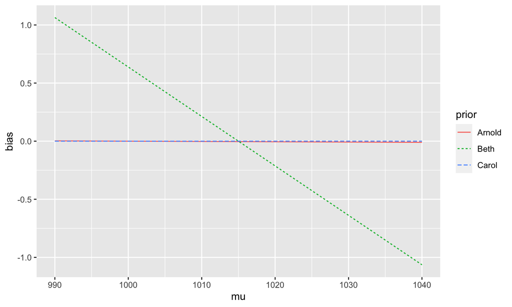

## mse

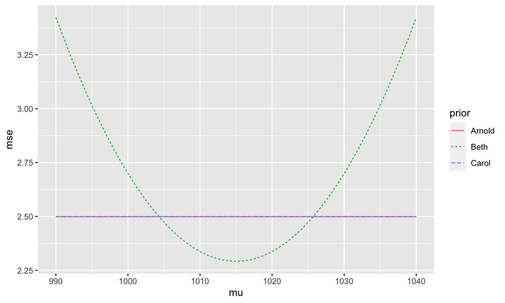

## You try:

Explore changing the sample size \(n\) and population variance \(\sigma^2\). How does it impact the evaluation above?

## 12.2.

Comparing Confidence and Credible Intervals for Mean

## Example 12.2 (continued from Example 11.3, p. 222)

Let’s discuss.

## 12.3 Testing a One-Sided Hypothesis about a Normal Mean

## Example 12.3 (continued from Example 11.3, p. 222)

Arne, Barb, and Chuck read in a journal that the mean length of yearling rainbow trout in a typical stream habitat is 31 cm. They each decide to determine if the mean length of trout in the stream they are researching is greater than that by testing

\[ H_0: \mu \leq 31 \: versus \: H_1: \mu > 31 \]

at the \(\alpha\) = 5% level. For one-sided Bayesian hypothesis tests, they calculate the posterior probability of the null hypothesis. Arnie and Barb have normal posteriors, so they use Equation 12.4. Chuck has a nonnormal posterior that he calculated numerically.

## Example 12.3

```r
compute_normalMean_normalPrior <- function(m, s2, n, y_bar, sigma2){
    ## posterior precision is the sum of prior and sample precision
    total_precision <- 1/s2 + n/sigma2
    s_prime2 <- 1/total_precision
    ## posterior mean is the weighted average of prior and sample mean
    m_prime <- ( (1/s2) / total_precision ) * m + ( (n/sigma2) / total_precision ) * y_bar
    ## return as a list
    list(m_prime=m_prime, s_prime2=s_prime2, s_prime = sqrt(s_prime2))
}

(arnie_post <- compute_normalMean_normalPrior(m = 30, s2 = 4^2, n = 12, y_bar = 32, sigma2 = 2^2))
```

```
## $m_prime
## [1] 31.95918
##
## $s_prime2
## [1] 0.3265306
##
## $s_prime
## [1] 0.5714286
```

## Example 12.3 con’d

```r
## P( m_prime <= mu0)
pnorm(q = 31, mean = arnie_post$m_prime, sd = arnie_post$s_prime)
```

```
## [1] 0.0466178
```

```r
## pnorm(q = 31, mean = 32, sd = 2^2 / 12)
```

## 12.4 Testing a Two-Sided Hypothesis about a Normal Mean

## Extend Example 12.3 (continued from Example 11.3, p. 222)

\[ H_0: \mu = 31 \: versus \: H_1: \mu \neq 31 \]

Let’s extend the last the example to test a two-sided hypothesis.

```r
Bolstad::normnp(x = rep(32, 12), m.x = 30, s.x = 4, sigma.x = 2)
```

```
## Known standard deviation :2
## Posterior mean           : 31.9591837
## Posterior std. deviation : 0.5714286
```

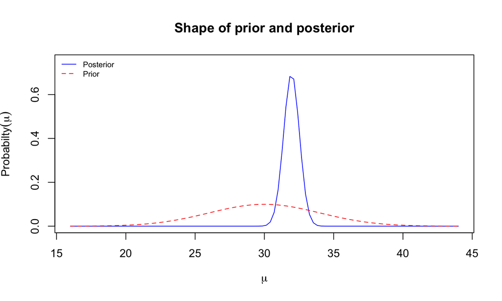

```
##
## Prob.    Quantile
## ------   ----------
## 0.005    30.4872812
## 0.010    30.6298420
## 0.025    30.8392043
## 0.050    31.0192673
## 0.500    31.9591837
## 0.950    32.8991000
## 0.975    33.0791631
## 0.990    33.2885253
## 0.995    33.4310861
```

## VI. Closing

Reply in the chat:

- When is Bayesian estimation of a Normal Mean preferred to Frequentist (in terms of MSE)?

### Notes

Exercise 12.2 has a typo: emphnormal is a \(\LaTeX\) typo. It is just *normal*\((75,10^2)\) .